# Practical Machine Learning Project

Aashay Harlalka

April 27, 2015

## Introduction

This is document describes the analysis I conducted for my final project for the Johns Hopkins’ Coursera course “Practical Machine Learning” in the Data Science specialization. You can learn more about the course [here](https://www.coursera.org/course/predmachlearn). All of my work was conducted in [RStudio](http://www.rstudio.com).

## Data

The data for this assignment comes from [here](http://groupware.les.inf.puc-rio.br/har), and contains information from belt, forearm, arm, and dumbbell accelerometers. The data are split into a training group (19,622) observations and testing group (20 observations). Participants in this study were asked to do a “Dumbbell Biceps Curl” in five different ways, including using correct form and four common mistakes. Participants were equipped with censors on the arm, belt and dumbbell itself.

## Method

First, I split the training set into 90/10 subsamples.

```r
set.seed(614)
library(lattice); library(ggplot2); library(caret)
pml.training <- read.csv("C:/Users/aashay.harlalka/Downloads/R/pml-training.csv")
inTrain <- createDataPartition(y=pml.training$classe, p=0.9, list=FALSE)
training <- pml.training[inTrain,]
testing <- pml.training[-inTrain,]
```

Note: To run this code, you will need to switch what is inside `read.csv("")` to your location of the data. The 90 percent subsample is used to train the modle, and the 10 percent sample is used for cross-validation. I chose this simple cross-validation rather than using something like K-fold via the `cv.folds` option to cut down on execution time, which was already quite lengthy. Next, I implement a Stochastic Gradient Boosting algorithm via the `gbm` package.

```r
ptm <- proc.time()
modFit <- train(classe ~ user_name + pitch_arm + yaw_arm + roll_arm + roll_belt + pitch_belt + yaw_belt + gyros_belt_x + gyros_belt_y + gyros_belt_z + accel_belt_x + accel_belt_y + accel_belt_z + magnet_belt_x + magnet_belt_y + magnet_belt_z + gyros_arm_x + gyros_arm_y + gyros_arm_z + accel_arm_x + accel_arm_y + accel_arm_z + magnet_arm_x + magnet_arm_y + magnet_arm_z + roll_dumbbell + pitch_dumbbell + yaw_dumbbell, method="gbm", data=training, verbose=FALSE)
proc.time() - ptm
```

```
##    user  system elapsed
## 1409.90   19.58 1437.84
```

To capture the execution time I’ve used `ptm` and `proc.time()`. On my machine the execution time was roughly 24 minutes.

```r
print(modFit)
```

[output not shown]

```r
predictTr <- predict(modFit,training)
table(predictTr, training$classe)
```

```
##
## predictTr    A    B    C    D    E
##         A 4749  145   51   39   37
##         B   75 3131  119   17   34
##         C   62  113 2839  138   18
##         D   98   14   63 2678   15
##         E   38   15    8   23 3143
```

The model correctly classifies 93.6 percent of the observations in the training sample using 150 trees. The “roll_belt”" and “yaw_belt”" features were by far the most important in terms of variable influence.

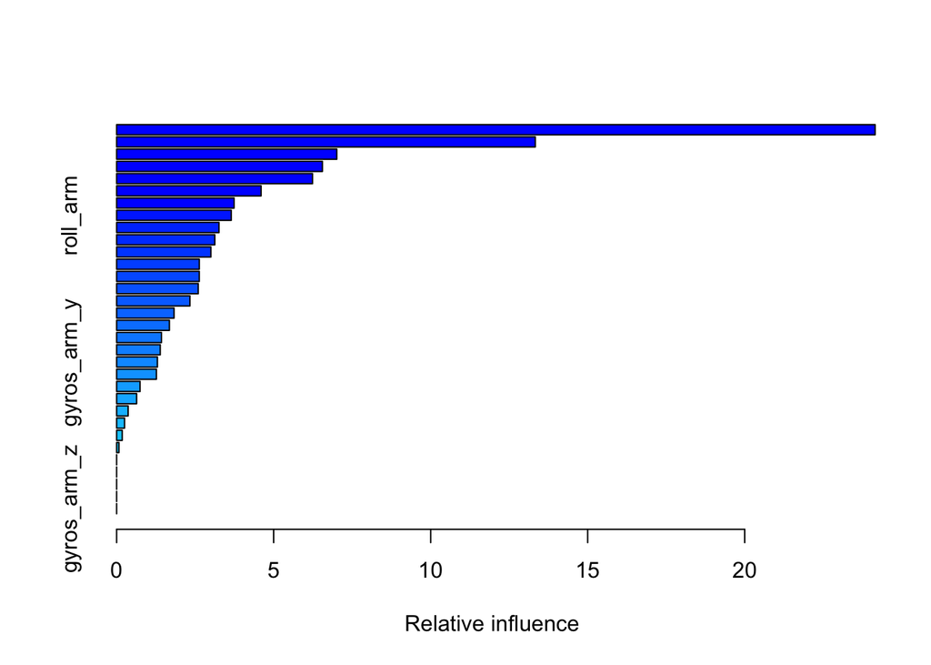

```
##                                 var  rel.inf
## roll_belt                 roll_belt 24.15343
## yaw_belt                   yaw_belt 13.33063
## magnet_belt_z         magnet_belt_z  7.01097
## roll_dumbbell         roll_dumbbell  6.55280
## pitch_belt               pitch_belt  6.23819
## magnet_arm_x           magnet_arm_x  4.59912
## accel_arm_x             accel_arm_x  3.74037
## roll_arm                   roll_arm  3.64898
## magnet_arm_z           magnet_arm_z  3.25981
## gyros_belt_z           gyros_belt_z  3.12695
## user_nameeurico     user_nameeurico  3.00163
## yaw_dumbbell           yaw_dumbbell  2.63164
## accel_arm_z             accel_arm_z  2.63096
## pitch_dumbbell       pitch_dumbbell  2.59930
## yaw_arm                     yaw_arm  2.33455
## magnet_belt_x         magnet_belt_x  1.82863
## pitch_arm                 pitch_arm  1.67995
## accel_belt_z           accel_belt_z  1.42771
## magnet_arm_y           magnet_arm_y  1.38889
## gyros_arm_y             gyros_arm_y  1.29886
## magnet_belt_y         magnet_belt_y  1.26592
## user_namecharles   user_namecharles  0.74598
## gyros_belt_y           gyros_belt_y  0.63706
## gyros_arm_x             gyros_arm_x  0.36557
## gyros_belt_x           gyros_belt_x  0.25119
## accel_arm_y             accel_arm_y  0.17786
## accel_belt_x           accel_belt_x  0.07305
## user_namecarlitos user_namecarlitos  0.00000
## user_namejeremy     user_namejeremy  0.00000
## user_namepedro       user_namepedro  0.00000
## accel_belt_y           accel_belt_y  0.00000
## gyros_arm_z             gyros_arm_z  0.00000
```

```r
summary(modFit,n.trees=150)
```

A plot of these top two features colored by outcome demonstrates their relative importance.

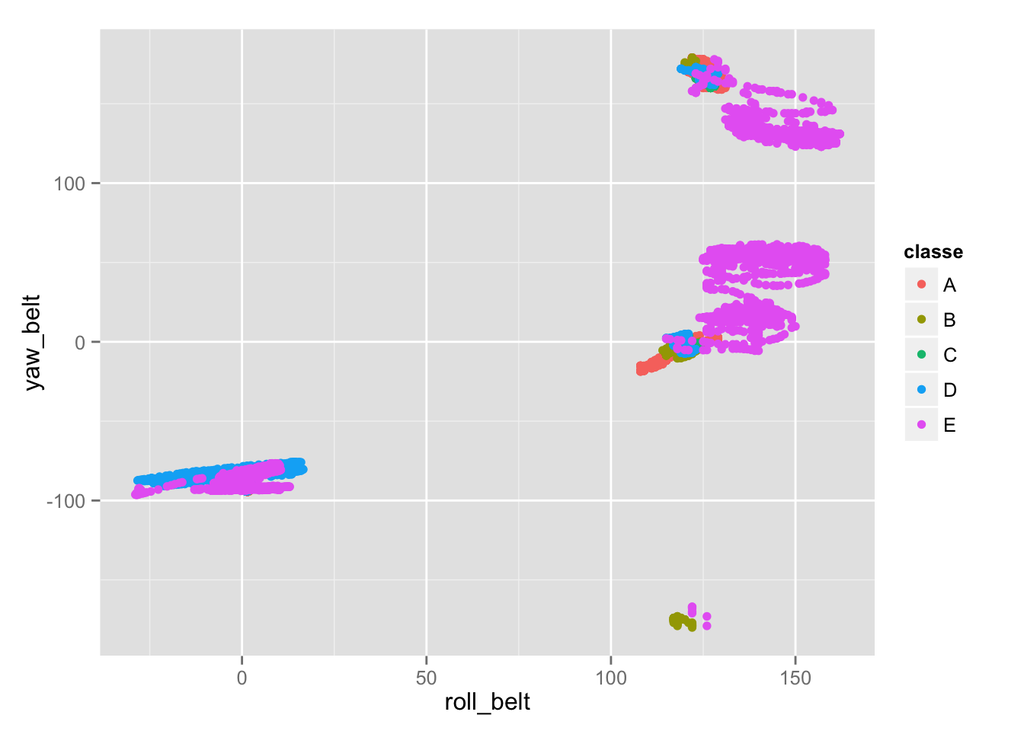

```r
qplot(roll_belt, yaw_belt,colour=classe,data=training)
```

Even though these are the top features, they’re still not great predictors in their own right. Nonetheless, you can see some bunching in this simple plot. This confirms the choice of a boosting algorithm as a good choice given the large set of relatively weak predictors. This next plot further demonstrates the improved performance gained by using boosting iterations.

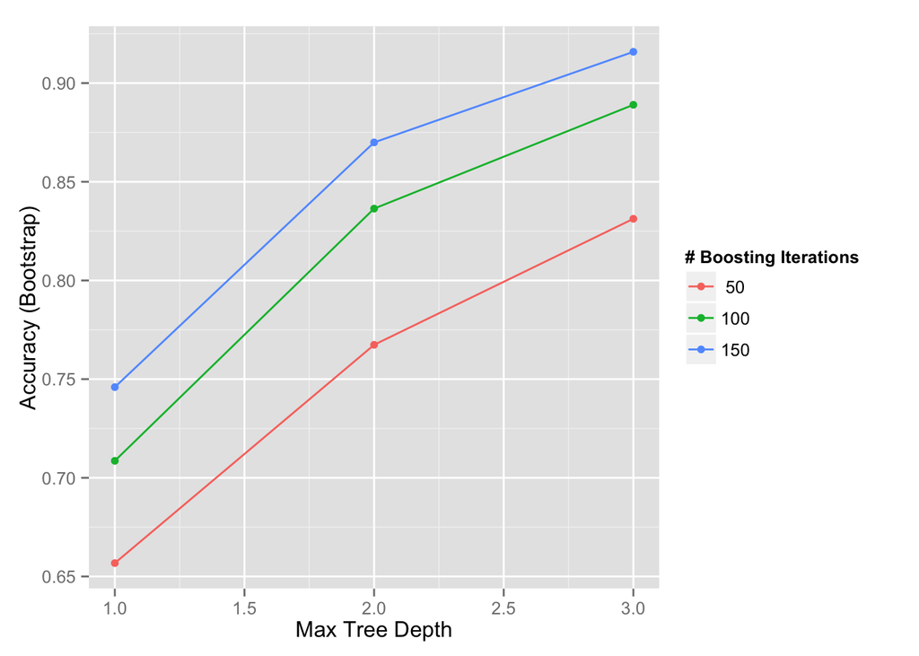

```r
ggplot(modFit)
```

Next, I check the performance on the 10 percent subsample to get an estimate of the algorithm’s out-of-sample performance.

```r
predictTe <- predict(modFit,testing)
table(predictTe, testing$classe)
```

```
##
## predictTe   A   B   C   D   E
##         A 530  19   4   2   6
##         B   3 346  16   0   5
##         C   4  13 312  19   3
##         D  15   1  10 297   0
##         E   6   0   0   3 346
```

The algorithm actually peforms only does slightly worse on the testing subset than it did on the full training set, correctly classifying 93.4 percent of the observations.

## Predicting on the Test Set

Finally, I use the algorithm to predict using the testing set. The results are run through the `pml_write_files()` function from the course Coursera site, and stored for submission.

```r
pml.testing <- read.csv("C:/Users/aashay.harlalka/Downloads/R/pml-testing.csv")
answers <- as.character(predict(modFit, pml.testing))
pml_write_files = function(x){
  n = length(x)
  for(i in 1:n){
    filename = paste0("problem_id_",i,".txt")
    write.table(x[i],file=filename,quote=FALSE,row.names=FALSE,col.names=FALSE)
  }
}
pml_write_files(answers)
```

After submitting these answers, it turns out that the algorithm correctly predicted the outcome for 20/20 observations further confirming its strong out-of-sample classification accuracy.